# Final Assignment

Mahammad Maharramov

1/3/2021

This is the RMarkDown for the Practical Machine Learning Course

```r
library(lattice); library(ggplot2); library(caret); library(randomForest); library(rpart); library(rpart.plot);
library(dplyr); library(rattle)
set.seed(2121)
```

Now we load our train and test data and do some pre-processing on them

```r
train_data <- read.csv(file.path("C:/Users/User/Documents/R Directory","pml-training.csv"), na.strings=c("NA","#DIV/0!", ""))
test_data <- read.csv(file.path("C:/Users/User/Documents/R Directory","pml-testing.csv"), na.strings=c("NA","#DIV/0!", ""))
train_data<-train_data[,colSums(is.na(train_data)) == 0]
test_data <-test_data[,colSums(is.na(test_data)) == 0]
train_data <-train_data[,-c(1:7)]
test_data <-test_data[,-c(1:7)]
```

Let us see what is the total number of records for each group in classe within our training data

```r
groupByClasse <- train_data %>%
  group_by(classe) %>%
  summarise(counts = n())
```

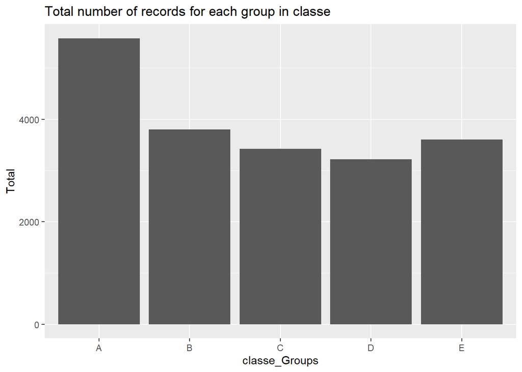

```r
g <- ggplot(groupByClasse, aes(x = classe, y = counts)) + geom_bar(stat = "identity")
g <- g + geom_bar(stat = "identity")
g <- g + ggtitle("Total number of records for each group in classe")
g <- g + xlab("classe_Groups")
g <- g + ylab("Total")
plot(g)
```

Now we use our train data set and partition it into train and test subsets

```r
index <- createDataPartition(y=train_data$classe, p=0.75, list=FALSE)
train <- train_data[index, ]
test <- train_data[-index, ]
```

My first model is the Random Forest Model

```r
controlRF <- trainControl(method="cv", number=3, verboseIter=FALSE)
model_RandForest <- train(classe ~ ., data=train, method="rf",
                          trControl=controlRF)

confusion_rand <- confusionMatrix(predict(model_RandForest, newdata=test), as.factor(test$classe))
confusion_rand
```

```
## Confusion Matrix and Statistics
##
##           Reference
## Prediction    A    B    C    D    E
##          A 1393    3    0    0    0
##          B    0  939    2    0    0
##          C    1    5  851    5    4
##          D    0    2    2  799    1
##          E    1    0    0    0  896
##
## Overall Statistics
##
##                Accuracy : 0.9947
##                  95% CI : (0.9922, 0.9965)
##     No Information Rate : 0.2845
##     P-Value [Acc > NIR] : < 2.2e-16
##
##                   Kappa : 0.9933
##
##  Mcnemar's Test P-Value : NA
##
## Statistics by Class:
##
##                      Class: A Class: B Class: C Class: D Class: E
## Sensitivity            0.9986   0.9895   0.9953   0.9938   0.9945
## Specificity            0.9991   0.9995   0.9963   0.9988   0.9998
## Pos Pred Value         0.9979   0.9979   0.9827   0.9938   0.9989
## Neg Pred Value         0.9994   0.9975   0.9990   0.9988   0.9988
## Prevalence             0.2845   0.1935   0.1743   0.1639   0.1837
## Detection Rate         0.2841   0.1915   0.1735   0.1629   0.1827
## Detection Prevalence   0.2847   0.1919   0.1766   0.1639   0.1829
## Balanced Accuracy      0.9989   0.9945   0.9958   0.9963   0.9971
```

The model with random forest ended up having around 99% accuracy which makes it harder for the other models to beat

The Second Model is the decision trees

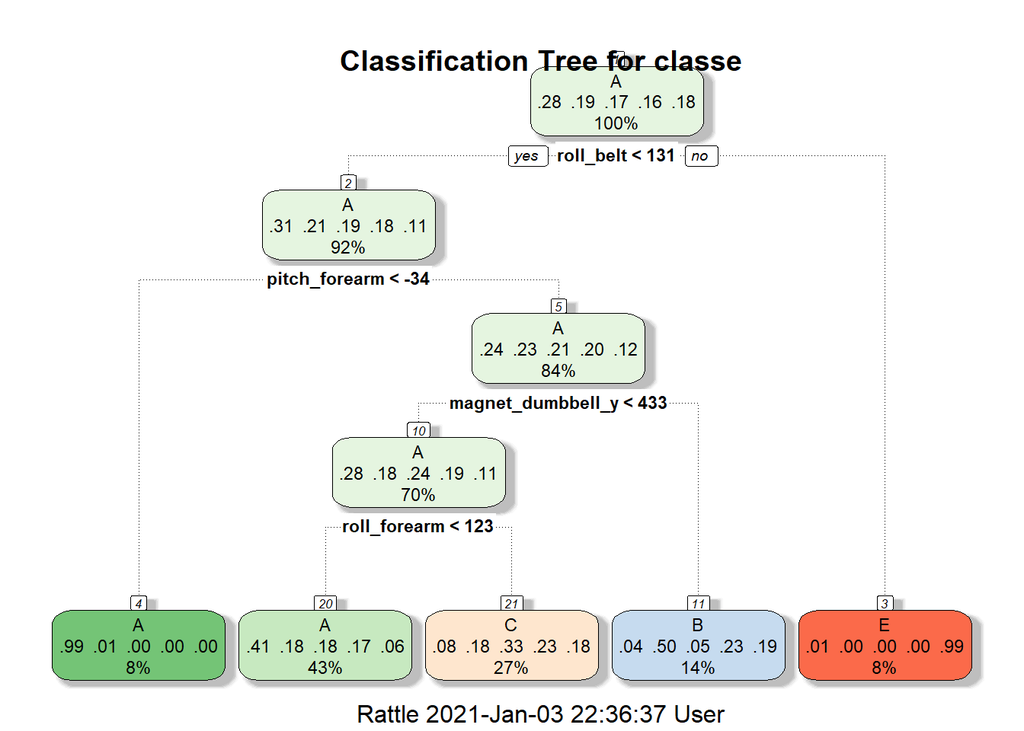

```r
decision_tree <- train(classe ~ ., data=train, method = "rpart")

# Normal plot
fancyRpartPlot(decision_tree$finalModel, main = "Classification Tree for classe")
```

```r
confusion_tree <- confusionMatrix(predict(decision_tree, newdata=test), as.factor(test$classe))
confusion_tree
```

```
## Confusion Matrix and Statistics
##
##           Reference
## Prediction    A    B    C    D    E
##          A 1261  392  411  355  114
##          B   29  328   22  150  124
##          C  102  229  422  299  230
##          D    0    0    0    0    0
##          E    3    0    0    0  433
##
## Overall Statistics
##
##                Accuracy : 0.4984
##                  95% CI : (0.4843, 0.5125)
##     No Information Rate : 0.2845
##     P-Value [Acc > NIR] : < 2.2e-16
##
##                   Kappa : 0.3446
##
##  Mcnemar's Test P-Value : NA
##
## Statistics by Class:
##
##                      Class: A Class: B Class: C Class: D Class: E
## Sensitivity            0.9039  0.34563  0.49357   0.0000  0.48058
## Specificity            0.6375  0.91783  0.78760   1.0000  0.99925
## Pos Pred Value         0.4978  0.50230  0.32917      NaN  0.99312
## Neg Pred Value         0.9435  0.85392  0.88045   0.8361  0.89526
## Prevalence             0.2845  0.19352  0.17435   0.1639  0.18373
## Detection Rate         0.2571  0.06688  0.08605   0.0000  0.08830
## Detection Prevalence   0.5165  0.13316  0.26142   0.0000  0.08891
## Balanced Accuracy      0.7707  0.63173  0.64058   0.5000  0.73991
```

The accuracy using Classification Tree turns out to be only 49%, given the pre-processing I considered. In the end we see that Random Forest is the winner here and can better predict the classe variable’s levels.

Now it is time to apply the Random Forest Model to the original test data and see how it performs when facing with the data it never used for training the model

```r
predict_TEST<-predict(model_RandForest,newdata = test_data)
predict_TEST
```

```
##  [1] B A B A A E D B A A B C B A E E A B B B
## Levels: A B C D E
```